# Part I - (Prosper Loan Data Exploration)

## Introduction

> This section is on the exploration of a financial data set that is related to loan, borrowers, lenders, interest rates, credit scores, etc, from Prosper Marketplace Inc, a San Francisco, California based company specialised in loans at low interest rates to the borrowers. Visualizations would be deployed to discover patterns, structures and underlying distributions of the financial data

## Preliminary Wrangling

```python
# import all packages and set plots to be embedded inline
import numpy as np
import pandas as pd
import matplotlib.pyplot as plt
import seaborn as sb

%matplotlib inline
```

### Data Gathering

```python
loan = pd.read_csv("prosperLoanData.csv") # Loading the data into a dataframe
```

### Data Assesment

> Visual Assesment

Programmatic Assesment

```python
loan.head(7)
```

|  | ListingKey | ListingNumber | ListingCreationDate | CreditGrade | Term | LoanStatus | ClosedDate | BorrowerAPR | BorrowerRate | LenderYield | ... | LP_ServiceFees | LP_CollectionFees | LP_GrossPrincipalLoss | LP_NetPrincipalLoss | LP_NonPrincipalRecoverypayments | PercentFunded | Recommendations | InvestmentFromFriendsCount | InvestmentFromFriendsAmount | Investors |
| --- | --- | --- | --- | --- | --- | --- | --- | --- | --- | --- | --- | --- | --- | --- | --- | --- | --- | --- | --- | --- | --- |
| 0 | 1021339766868145413AB3B | 193129 | 2007-08-26 19:09:29.263000000 | C | 36 | Completed | 2009-08-14 00:00:00 | 0.16516 | 0.1580 | 0.1380 | ... | -133.18 | 0.0 | 0.0 | 0.0 | 0.0 | 1.0 | 0 | 0 | 0.0 | 258 |
| 1 | 10273602499503308B223C1 | 1209647 | 2014-02-27 08:28:07.900000000 | NaN | 36 | Current | NaN | 0.12016 | 0.0920 | 0.0820 | ... | 0.00 | 0.0 | 0.0 | 0.0 | 0.0 | 1.0 | 0 | 0 | 0.0 | 1 |
| 2 | 0EE9337825851032864889A | 81716 | 2007-01-05 15:00:47.090000000 | HR | 36 | Completed | 2009-12-17 00:00:00 | 0.28269 | 0.2750 | 0.2400 | ... | -24.20 | 0.0 | 0.0 | 0.0 | 0.0 | 1.0 | 0 | 0 | 0.0 | 41 |
| 3 | 0EF5356002482715299901A | 658116 | 2012-10-22 11:02:35.010000000 | NaN | 36 | Current | NaN | 0.12528 | 0.0974 | 0.0874 | ... | -108.01 | 0.0 | 0.0 | 0.0 | 0.0 | 1.0 | 0 | 0 | 0.0 | 158 |
| 4 | 0F023589499656230C5E3E2 | 909464 | 2013-09-14 18:38:39.097000000 | NaN | 36 | Current | NaN | 0.24614 | 0.2085 | 0.1985 | ... | -60.27 | 0.0 | 0.0 | 0.0 | 0.0 | 1.0 | 0 | 0 | 0.0 | 20 |
| 5 | 0F05359734824199381F61D | 1074836 | 2013-12-14 08:26:37.093000000 | NaN | 60 | Current | NaN | 0.15425 | 0.1314 | 0.1214 | ... | -25.33 | 0.0 | 0.0 | 0.0 | 0.0 | 1.0 | 0 | 0 | 0.0 | 1 |
| 6 | 0F0A3576754255009D63151 | 750899 | 2013-04-12 09:52:56.147000000 | NaN | 36 | Current | NaN | 0.31032 | 0.2712 | 0.2612 | ... | -22.95 | 0.0 | 0.0 | 0.0 | 0.0 | 1.0 | 0 | 0 | 0.0 | 1 |

7 rows × 81 columns

```python
loan.shape # investigating the dimension of data set
```

```
(113937, 81)
```

```python
loan.info() # gives basic information of data sets
```

```
<class 'pandas.core.frame.DataFrame'>
RangeIndex: 113937 entries, 0 to 113936
Data columns (total 81 columns):
 #   Column                               Non-Null Count   Dtype
---  ------                               --------------   -----
 0   ListingKey                           113937 non-null  object
 1   ListingNumber                        113937 non-null  int64
 2   ListingCreationDate                  113937 non-null  object
 3   CreditGrade                          28953 non-null   object
 4   Term                                 113937 non-null  int64
 5   LoanStatus                           113937 non-null  object
 6   ClosedDate                           55089 non-null   object
 7   BorrowerAPR                          113912 non-null  float64
 8   BorrowerRate                         113937 non-null  float64
 9   LenderYield                          113937 non-null  float64
```

[output cut: 73 more lines]

## Assessment Summary

Data Cleaning and Accessing procedures

- Choose features that are of interest for this analysis
- Drop Duplicated rows with listing number as criteria
- drop all rows without prosper rating
- converlisting creation dates to datwtime and break into days, months and years
- DEFINE: choose features that are of interest for the analysis
- CODE

```python
columns = ['ListingNumber','ListingCreationDate','CreditGrade','Term','LoanStatus','LoanOriginalAmount','BorrowerAPR','LenderYield',
               'EstimatedReturn', 'EmploymentStatus', 'ProsperRating (Alpha)','ListingCategory (numeric)','IncomeRange','MonthlyLoanPayment','StatedMonthlyIncome','DebtToIncomeRatio']
df_loan = loan[columns]
```

- TEST

```python
df_loan.info()
```

```
<class 'pandas.core.frame.DataFrame'>
RangeIndex: 113937 entries, 0 to 113936
Data columns (total 16 columns):
 #   Column                     Non-Null Count   Dtype
---  ------                     --------------   -----
 0   ListingNumber              113937 non-null  int64
 1   ListingCreationDate        113937 non-null  object
 2   CreditGrade                28953 non-null   object
 3   Term                       113937 non-null  int64
 4   LoanStatus                 113937 non-null  object
 5   LoanOriginalAmount         113937 non-null  int64
 6   BorrowerAPR                113912 non-null  float64
 7   LenderYield                113937 non-null  float64
 8   EstimatedReturn            84853 non-null   float64
 9   EmploymentStatus           111682 non-null  object
 10  ProsperRating (Alpha)      84853 non-null   object
 11  ListingCategory (numeric)  113937 non-null  int64
 12  IncomeRange                113937 non-null  object
 13  MonthlyLoanPayment         113937 non-null  float64
 14  StatedMonthlyIncome        113937 non-null  float64
 15  DebtToIncomeRatio          105383 non-null  float64
dtypes: float64(6), int64(4), object(6)
memory usage: 13.9+ MB
```

```python
# drop duplicates in the dataset
df_loan = df_loan.drop_duplicates()
```

```python
# selecting rows only where ProsperRating is not null as this is one of the most important features of the dataset
# and filling in missing values is not possible.
df_loan = df_loan[df_loan['ProsperRating (Alpha)'].notnull()]
```

```python
df_loan.info()
```

```
<class 'pandas.core.frame.DataFrame'>
Int64Index: 83982 entries, 1 to 113936
Data columns (total 16 columns):
 #   Column                     Non-Null Count  Dtype
---  ------                     --------------  -----
 0   ListingNumber              83982 non-null  int64
 1   ListingCreationDate        83982 non-null  object
 2   CreditGrade                0 non-null      object
 3   Term                       83982 non-null  int64
 4   LoanStatus                 83982 non-null  object
 5   LoanOriginalAmount         83982 non-null  int64
 6   BorrowerAPR                83982 non-null  float64
 7   LenderYield                83982 non-null  float64
 8   EstimatedReturn            83982 non-null  float64
 9   EmploymentStatus           83982 non-null  object
 10  ProsperRating (Alpha)      83982 non-null  object
 11  ListingCategory (numeric)  83982 non-null  int64
 12  IncomeRange                83982 non-null  object
 13  MonthlyLoanPayment         83982 non-null  float64
 14  StatedMonthlyIncome        83982 non-null  float64
 15  DebtToIncomeRatio          76768 non-null  float64
dtypes: float64(6), int64(4), object(6)
memory usage: 10.9+ MB
```

```python
# Splitting ListingCreationDate column into year,month,day,time
df_loan['year']=df_loan['ListingCreationDate'].apply(lambda x: x.split("-")[0]).astype(str)
df_loan['month'] = df_loan['ListingCreationDate'].apply(lambda x: x.split("-")[1]).astype(str)
df_loan['ListingCreationDate'] = df_loan['ListingCreationDate'].apply(lambda x: x.split("-")[2]).astype(str)
```

```python
# replacing numerical values of month with names
df_loan.month.replace(['01','02','03','04','05','06','07','08','09','10','11','12'],['Jan','Feb','Mar','Apr','May','Jun','Jul','Aug','Sept','Oct','Nov','Dec'],inplace=True)
```

```python
df_loan.shape
```

```
(83982, 18)
```

### What is the structure of your dataset?

> The Shape method shows that there are 113,937 loans in the dataset with 81 features.

### What is/are the main feature(s) of interest in your dataset?

> I am most interested in the features that affect the borrowers APR and the loan status

### What features in the dataset do you think will help support your investigation into your feature(s) of interest?

- IncomeRange - The income range of the borrower at the time the listing was created.
- DebToIncomeRatio - The debt to income ratio of the borrower at the time the credit profile was pulled. This value is Null if the debt to income ratio is not available. This value is capped at 10.01 (any debt to income ratio larger than 1000% will be returned as 1001%).
- ProsperRating (Alpha) - The Prosper Rating assigned at the time the listing was created between AA - HR. Applicable for loans originated after July 2009.
- Listing category and the employment status of the borrower
- Principal

## Univariate Exploration

- I would start by examining the variable of interest - the borrowers APR

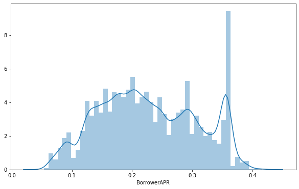

```python
plt.figure(figsize=[10,6])
sb.distplot(df_loan['BorrowerAPR']);
```

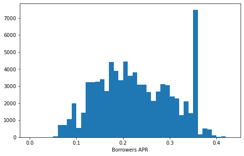

```python
binsize = 0.01
bins = np.arange(0, df_loan['BorrowerAPR'].max()+binsize, binsize)

plt.figure(figsize=[8, 5])
plt.hist(data = df_loan, x = 'BorrowerAPR', bins = bins)
plt.xlabel('Borrowers APR')
plt.show()
```

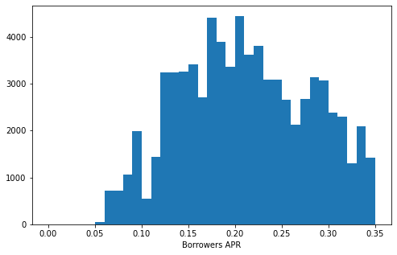

```python
# Plotting on a smaller scale

binsize = 0.01
bins = np.arange(0, 0.35+binsize, binsize)

plt.figure(figsize=[8, 5])
plt.hist(data = df_loan, x = 'BorrowerAPR', bins = bins)
plt.xlabel('Borrowers APR')
plt.show()
```

We proceed to examine other factors that can affect borrowers APR

```python
# filling the empty rows of debt to income ratio with means

dti_mean = df_loan['DebtToIncomeRatio'].mean()
df_loan['DebtToIncomeRatio'].fillna(value=dti_mean, inplace=True)
```

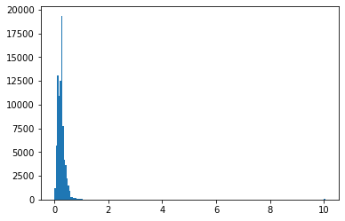

```python
dti_binsize = 0.05 #Debt to income ratio binsize
dti_bins = np.arange(0, df_loan['DebtToIncomeRatio'].max()+dti_binsize, dti_binsize)
plt.hist(data = df_loan, x='DebtToIncomeRatio', bins = dti_bins, label = 'Histogram of Debt to income Ratio')
plt.show()
```

```python
df_loan['DebtToIncomeRatio'].describe()
```

```
count    83982.000000
mean         0.258692
std          0.305687
min          0.000000
25%          0.160000
50%          0.240000
75%          0.310000
max         10.010000
Name: DebtToIncomeRatio, dtype: float64
```

It seems data values just fall between 0 and 3, and others might be outliers

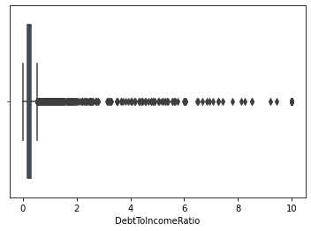

```python
# further investigating with a boxplot
sb.boxplot(data = df_loan, x='DebtToIncomeRatio')
```

seems our hunch was right!!!. We would remove this outliers and plot the histogram again to get their distribution

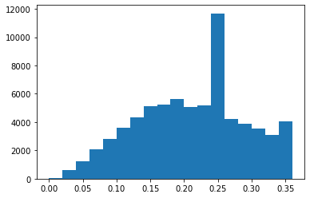

```python
dti_binsize = 0.02 #Debt to income ratio binsize
dti_bins = np.arange(0, 0.35+dti_binsize, dti_binsize)
plt.hist(data = df_loan, x='DebtToIncomeRatio', bins = dti_bins, label = 'Histogram of Debt to income Ratio')
plt.show()
```

This gives a better view on the debt to income ratio, with just a pike or peak at the 0.25 mark without which we can easily see its normal shape

- We proceed by examining other factors that are likely to affect borrowers APR

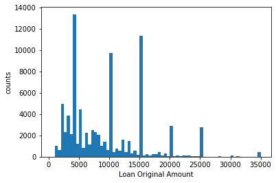

```python
# this plot gives the histogram for the loan original amaount

# create bins

bins = np.arange(500, 35000+500, 500)

# plot

plt.hist(data=df_loan, x = 'LoanOriginalAmount', bins = bins, label='Histogram of loan originla amount')

# name labels

plt.xlabel('Loan Original Amount')
plt.ylabel('counts')
#plt.xscale('log')
```

Loan Original amount seems to follow a pattern. They show peaks at every 5000 interval and then fall steadily only to rise up again

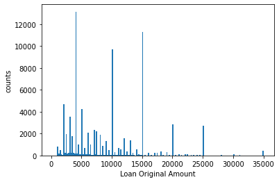

```python
# investigating further with smaller binsize
# create bins

bins = np.arange(200, 35000+200, 200)

# plot

plt.hist(data=df_loan, x = 'LoanOriginalAmount', bins = bins, label='Histogram of loan originla amount')

# name labels

plt.xlabel('Loan Original Amount')
plt.ylabel('counts')
#plt.xscale('log')
```

```python
#reform the listing cateogry variables to take up their values by replacing their values with corresponding letters

df_loan['ListingCategory'] = df_loan.replace({'ListingCategory (numeric)': {0: 'Not Available',
                                       1: 'Debt Consolidation', 2: 'Home Improvement', 3: 'Business', 4: 'Personal Loan', 5: 'Students Use',
                                       6: 'Auto', 7:'Other', 8: 'Baby&Adoption', 9:'Boat', 10:'Cosmetic Procedure', 11:'Engagement Ring', 12:'Green Loans',
                                       13:'Household Expenses', 14:'Large Purchases', 15:'Medical/Dental', 16:'Motorcycle', 17:'RV', 18:'Taxes', 19:'Vacation',
                                       20:'Wedding Loans'}}, inplace=True)
```

Moving on to other categorical variables needed for our investigation

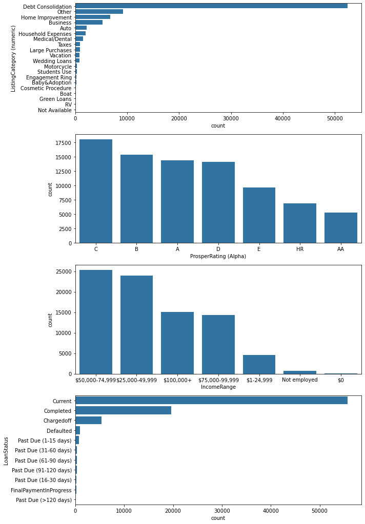

```python
# let's plot all three together to get an idea of each ordinal variable's distribution.

listing_order = df_loan['ListingCategory (numeric)'].value_counts().index
prosper_order = df_loan['ProsperRating (Alpha)'].value_counts().index
income_order = df_loan['IncomeRange'].value_counts().index
loan_status_order = df_loan['LoanStatus'].value_counts().index
fig, ax = plt.subplots(nrows=4, figsize = [10,18])

default_color = sb.color_palette()[0]
sb.countplot(data = df_loan, y = 'ListingCategory (numeric)', color = default_color, ax = ax[0], order=listing_order)
sb.countplot(data = df_loan, x = 'ProsperRating (Alpha)', color = default_color, ax = ax[1], order=prosper_order)
sb.countplot(data = df_loan, x = 'IncomeRange', color = default_color, ax = ax[2], order=income_order)
sb.countplot(data = df_loan, y = 'LoanStatus', color = default_color, ax = ax[3], order=loan_status_order)
plt.show()
```

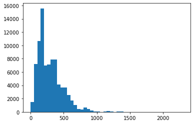

```python
bins = np.arange(0,df_loan['MonthlyLoanPayment'].max()+50,50)
plt.hist(data=df_loan,x='MonthlyLoanPayment', bins=bins);
```

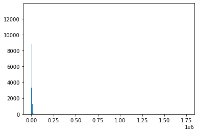

```python
bins = np.arange(0,df_loan['StatedMonthlyIncome'].max()+1000,1000)
plt.hist(data=df_loan,x='StatedMonthlyIncome', bins=bins);
```

```python
df_loan['StatedMonthlyIncome'].describe()
```

```
count    8.398200e+04
mean     5.930614e+03
std      8.268432e+03
min      0.000000e+00
25%      3.426938e+03
50%      5.000000e+03
75%      7.083333e+03
max      1.750003e+06
Name: StatedMonthlyIncome, dtype: float64
```

### Discuss the distribution(s) of your variable(s) of interest. Were there any unusual points? Did you need to perform any transformations?

> The borrower APR shows almost a normal distrubution if not a large pike almost at the end of the distribution Reducing the scale shows a distribution that is approximately normal The Loan status variable shows its mode to be current

### Of the features you investigated, were there any unusual distributions? Did you perform any operations on the data to tidy, adjust, or change the form of the data? If so, why did you do this?

> There were certain pikes at regular intervals in the loan original amount. Reducing the bin size showed this

## Bivariate Exploration

> To start off with, I want to look at the pairwise correlations present between features in the data.

```python
numeric_vars = ['LoanOriginalAmount','DebtToIncomeRatio','Term','BorrowerAPR','MonthlyLoanPayment','StatedMonthlyIncome']
cat_vars = ['LoanStatus','ListingCategory (numeric)','IncomeRange','ProsperRating (Alpha)']
```

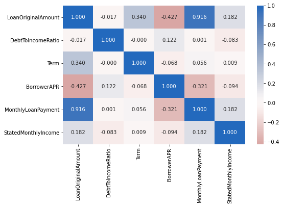

```python
# correlation plot
plt.figure(figsize = [8, 5])
sb.heatmap(df_loan[numeric_vars].corr(), annot = True, fmt = '.3f',
           cmap = 'vlag_r', center = 0)
plt.show()
```

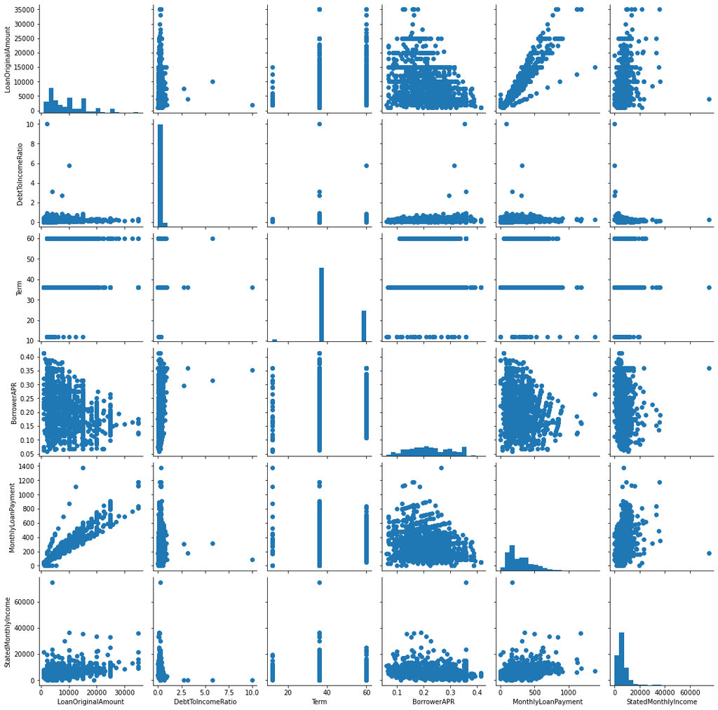

```python
# plot scatter matrix using a random sample of the data set(n=1500), for clearity and speed

loan_samp = df_loan.sample(n=1500, replace = False) # Random sample of the df_loan

g = sb.PairGrid(data = loan_samp, vars = numeric_vars)
g = g.map_diag(plt.hist, bins = 20);
g.map_offdiag(plt.scatter)
```

```python
df_loan['ProsperRating (Alpha)'].unique()
```

```
array(['A', 'D', 'B', 'E', 'C', 'AA', 'HR'], dtype=object)
```

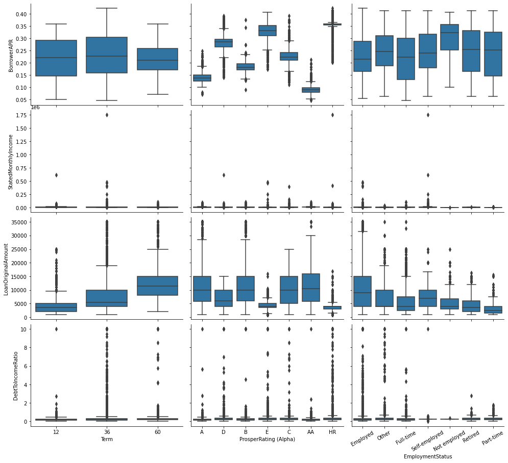

```python
# plot matrix of numeric features against categorical features.

def boxgrid(x, y, **kwargs):
    """ Quick hack for creating box plots with seaborn's PairGrid. """
    default_color = sb.color_palette()[0]
    sb.boxplot(x, y, color = default_color)

plt.figure(figsize = [10, 10])
g = sb.PairGrid(data = df_loan, y_vars = ['BorrowerAPR', 'StatedMonthlyIncome', 'LoanOriginalAmount','DebtToIncomeRatio'],
                x_vars = ['Term','ProsperRating (Alpha)', 'EmploymentStatus'], height = 3, aspect = 1.5)
g.map(boxgrid);
plt.xticks(rotation=30);
```

Lets compare the categorical variables amongst themselves

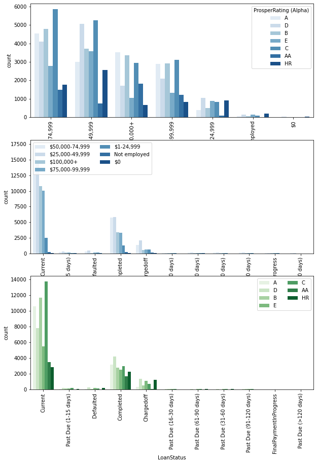

```python
plt.figure(figsize = [10, 14])

# subplot 1: color vs cut
plt.subplot(3, 1, 1)
sb.countplot(data = df_loan, x = 'IncomeRange', hue = 'ProsperRating (Alpha)', palette = 'Blues')
plt.xticks(rotation=90)
# subplot 2: clarity vs. cut
ax = plt.subplot(3, 1, 2)
sb.countplot(data = df_loan, x = 'LoanStatus', hue = 'IncomeRange', palette = 'Blues')
ax.legend(ncol = 2) # re-arrange legend to reduce overlapping
plt.xticks(rotation=90)
# subplot 3: clarity vs. color, use different color palette
ax = plt.subplot(3, 1, 3)
sb.countplot(data = df_loan, x = 'LoanStatus', hue = 'ProsperRating (Alpha)', palette = 'Greens')
ax.legend(loc = 1, ncol = 2) # re-arrange legend to remove overlapping

plt.xticks(rotation=90)
plt.show()
```

We would only work with completed, current, Defaulted and charged off

```python
df_loan_status = df_loan.query(' LoanStatus == "Current" or LoanStatus =="Completed" or LoanStatus=="Defaulted" or LoanStatus=="Chargedoff" ')
```

```python
df_loan_status.head()
```

|  | ListingNumber | ListingCreationDate | CreditGrade | Term | LoanStatus | LoanOriginalAmount | BorrowerAPR | LenderYield | EstimatedReturn | EmploymentStatus | ProsperRating (Alpha) | ListingCategory (numeric) | IncomeRange | MonthlyLoanPayment | StatedMonthlyIncome | DebtToIncomeRatio | year | month | ListingCategory |
| --- | --- | --- | --- | --- | --- | --- | --- | --- | --- | --- | --- | --- | --- | --- | --- | --- | --- | --- | --- |
| 1 | 1209647 | 27 08:28:07.900000000 | NaN | 36 | Current | 10000 | 0.12016 | 0.0820 | 0.05470 | Employed | A | Home Improvement | $50,000-74,999 | 318.93 | 6125.000000 | 0.18 | 2014 | Feb | None |
| 3 | 658116 | 22 11:02:35.010000000 | NaN | 36 | Current | 10000 | 0.12528 | 0.0874 | 0.06000 | Employed | A | Motorcycle | $25,000-49,999 | 321.45 | 2875.000000 | 0.15 | 2012 | Oct | None |
| 4 | 909464 | 14 18:38:39.097000000 | NaN | 36 | Current | 15000 | 0.24614 | 0.1985 | 0.09066 | Employed | D | Home Improvement | $100,000+ | 563.97 | 9583.333333 | 0.26 | 2013 | Sept | None |
| 5 | 1074836 | 14 08:26:37.093000000 | NaN | 60 | Current | 15000 | 0.15425 | 0.1214 | 0.07077 | Employed | B | Debt Consolidation | $100,000+ | 342.37 | 8333.333333 | 0.36 | 2013 | Dec | None |
| 6 | 750899 | 12 09:52:56.147000000 | NaN | 36 | Current | 3000 | 0.31032 | 0.2612 | 0.11070 | Employed | E | Debt Consolidation | $25,000-49,999 | 122.67 | 2083.333333 | 0.27 | 2013 | Apr | None |

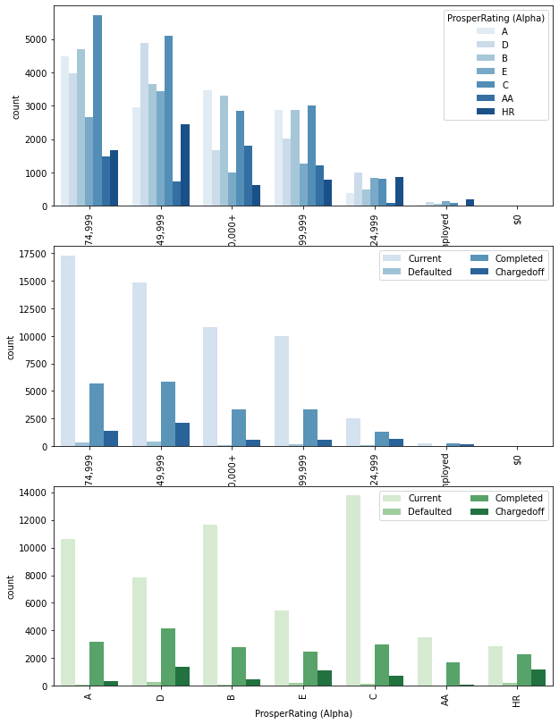

```python
plt.figure(figsize = [10, 14])

# subplot 1: color vs cut
plt.subplot(3, 1, 1)
sb.countplot(data = df_loan_status, x = 'IncomeRange', hue = 'ProsperRating (Alpha)', palette = 'Blues')
plt.xticks(rotation=90)
# subplot 2: clarity vs. cut
ax = plt.subplot(3, 1, 2)
sb.countplot(data = df_loan_status, hue = 'LoanStatus', x = 'IncomeRange', palette = 'Blues')
ax.legend(ncol = 2) # re-arrange legend to reduce overlapping
plt.xticks(rotation=90)
# subplot 3: clarity vs. color, use different color palette
ax = plt.subplot(3, 1, 3)
sb.countplot(data = df_loan_status, hue = 'LoanStatus', x = 'ProsperRating (Alpha)', palette = 'Greens')
ax.legend(loc = 1, ncol = 2) # re-arrange legend to remove overlapping

plt.xticks(rotation=90)
plt.show()
```

[figure not shown]

```python
# lets compare loan original amount with monthly loan payment

plt.figure(figsize = [8, 6])
plt.scatter(data = df_loan, y = 'MonthlyLoanPayment', x = 'StatedMonthlyIncome', alpha = 1/10)
plt.xlabel('Monthly Stated Income')
plt.ylabel('Loan Original Amount')
plt.show()
```

```python
df_loan_status.LoanStatus.value_counts()
```

```
Current       55730
Completed     19651
Chargedoff     5336
Defaulted      1005
Name: LoanStatus, dtype: int64
```

### Talk about some of the relationships you observed in this part of the investigation. How did the feature(s) of interest vary with other features in the dataset?

> Borrower APR didnt show much positive strong correlation among numerical variables. Loan Original Amount showed strong positibe relatiionship with monthly loan payment. It was seen from boxplot that borrower APR seems to be equal across term/length of loan

## Multivariate Exploration

> In this section, i just want to explore how other variables affect the variables of interest which are Borrower APR and Loan status.
> - How does borrower APR and debt to income ratio affect loan status.
> - was the prosper rating efficient for the above findings?

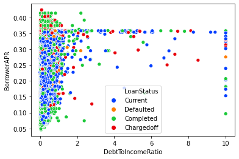

```python
sb.scatterplot(data=df_loan_status, x='DebtToIncomeRatio', y='BorrowerAPR',hue='LoanStatus', palette='bright',);
```

The plot shows that completed loans are loans with either low or high borrower percentage rate and these are borrowers with very low debt to income ratio. This affirms the fact that only borrowers with low debt to income ratio are most likely to get loans.

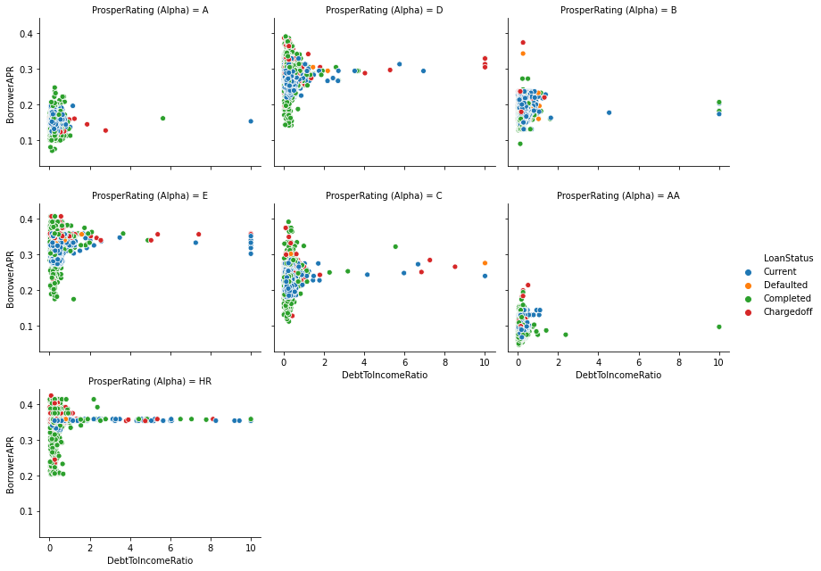

```python
sb.relplot(x='DebtToIncomeRatio', y='BorrowerAPR', data=df_loan_status,
           kind='scatter', hue='LoanStatus', col='ProsperRating (Alpha)',
          height=3, aspect=1.3,col_wrap=3);
```

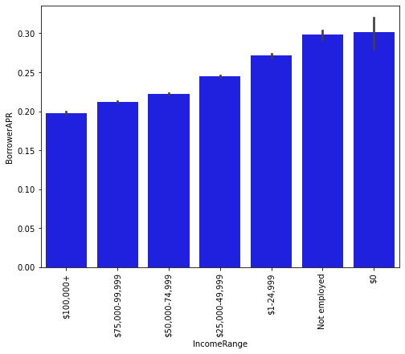

```python
plt.figure(figsize=[8,6])
order = ['$100,000+', '$75,000-99,999','$50,000-74,999', '$25,000-49,999',
       '$1-24,999', 'Not employed', '$0']

sb.barplot(
    x='IncomeRange',
    y='BorrowerAPR',
    data=df_loan_status,
    color='blue', order = order);    #hue='LoanStatus');
plt.xticks(rotation = 90);
```

From plot, we see that borrowers with no employment or zero incomes are the ones with high percentage rate. This might be because of these individuals apply for loans as a start up capital for their business and so their loans will be much, leading to a higher percentage rate. Lets compare the income range with the Loan Original Amount to see the verity of this.

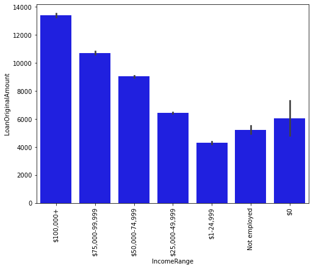

```python
plt.figure(figsize=[8,6])
order = ['$100,000+', '$75,000-99,999','$50,000-74,999', '$25,000-49,999',
       '$1-24,999', 'Not employed', '$0']
sb.barplot(
    x='IncomeRange',
    y='LoanOriginalAmount',
    data=df_loan_status,
    color='blue',
    order=order);    #hue='LoanStatus');
plt.xticks(rotation = 90);
```

It seems quite the opposite, borrowers with lesser income or no employment seems to receive lesser loans. This can follow the logical reason that it is those who have collaterals that would be entrusted with loans. And to him who has, more would be given to him

Could this question the generic principle of fairness?. Why does the rich receive higher loans yet get lesser percentage? Lets compare this with the length or term of the loans to get to the bottom of this.

Is it just that people with longer term of payments, get lower interest rates and higher loans or there is something fishy underneath this.

Lets compare the above results with their terms

```python
df_loan['Term'] = df_loan['Term'].astype(str)
```

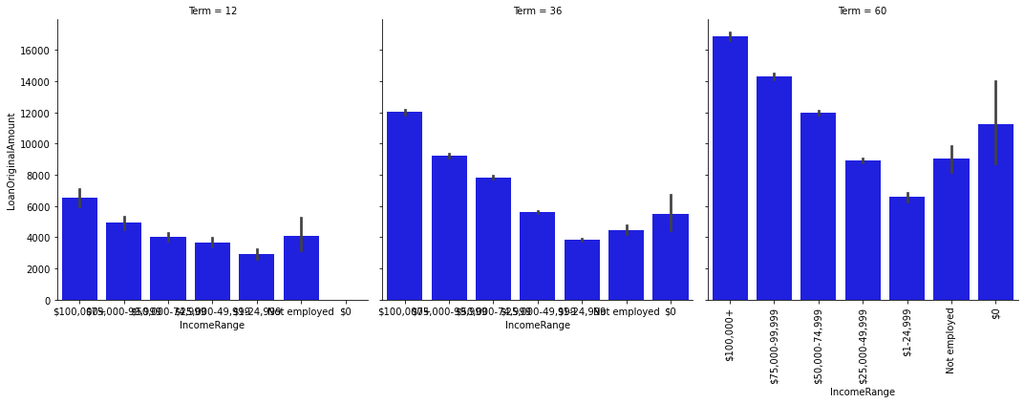

```python
plt.figure(figsize=[8,6])
order = ['$100,000+', '$75,000-99,999','$50,000-74,999', '$25,000-49,999',
       '$1-24,999', 'Not employed', '$0']
sb.catplot(
    x='IncomeRange',
    y='LoanOriginalAmount',
    data=df_loan_status,
    color='blue',
    kind='bar',
    order=order,
    col='Term')
plt.xticks(rotation = 90);
```

### Were there any interesting or surprising interactions between features?

> Generally, a larger loan payment would hence mean lower interest rate from analysis.

```python
df_loan.to_csv('df_loan.csv')
```